# Confidence Intervals

we’ll look at the relationship between being a physically active adult and weight using confidence intervals.

load libraries

```r
library(tidyverse)
library(NHANES)
```

prep data

```r
NHANES_adult <- NHANES %>%
  filter(Age > 17 & !is.na(PhysActive) & !is.na(Weight)) %>%
  select(ID, PhysActive, Weight) %>%
  unique()
nrow(NHANES_adult) # size of our "population"
```

```
[1] 4792
```

### theoretical CI using sample

the most likely scenario when we want to estimate a population parameter is that we have a sample on which we can compute the estimate. let’s sample 100 people from the NHANES dataset, and use the t distribution to find our critical values.

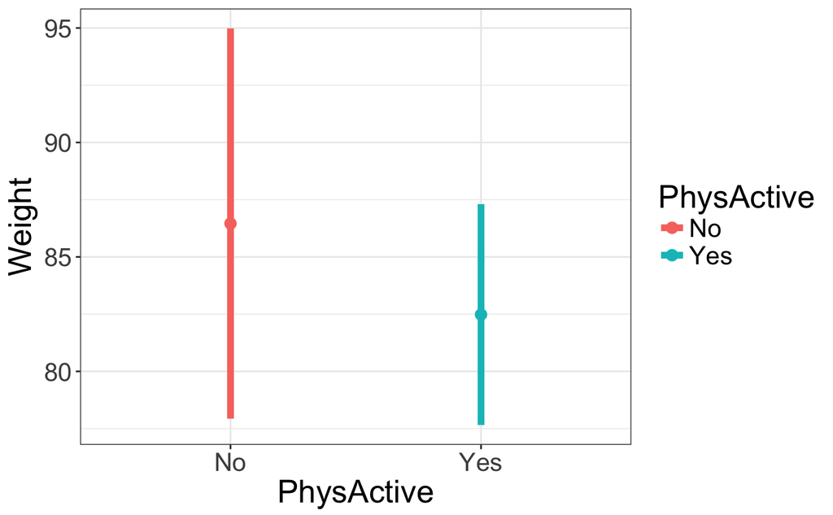

```r
NHANES_sample <- NHANES_adult %>%
  sample_n(100)
weight_sample_summary <- NHANES_sample %>%
  group_by(PhysActive) %>%
  summarise(n = n(),
            mean = mean(Weight),
            se = sd(Weight)/sqrt(n),
            crit_val_lower = qt(.025, df = n - 1),
            crit_val_upper = qt(.975, df = n - 1),
            ci_lower = mean + crit_val_lower * se,
            ci_upper = mean + crit_val_upper * se)
ggplot(weight_sample_summary, aes(PhysActive, mean, color = PhysActive)) +
  geom_point(size = 3) +
  geom_errorbar(aes(ymin = ci_lower, ymax = ci_upper), width = 0, size = 2) +
  ylab("Weight") +
  theme(text=element_text(size=20))
```

### theoretical CI using “population”

for comparison, let’s say the entire NHANES dataset is the entire population of interest (N=4792). we can use the z distribution to find our critical values, because the true population mean is known. in this example, we are still assuming that true population standard deviation sigma is unknown.

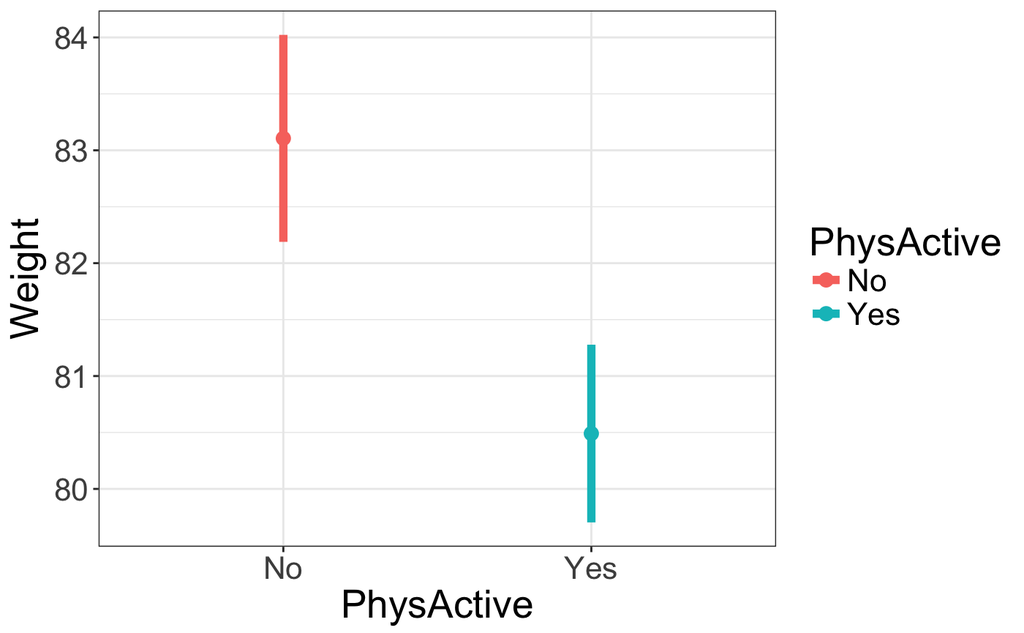

```r
weight_summary <- NHANES_adult %>%
  group_by(PhysActive) %>%
  summarise(n = n(),
            mean = mean(Weight),
            se = sd(Weight)/sqrt(n),
            crit_val_lower = qnorm(.025),
            crit_val_upper = qnorm(.975),
            ci_lower = mean + crit_val_lower * se,
            ci_upper = mean + crit_val_upper * se)
ggplot(weight_summary, aes(PhysActive, mean, color = PhysActive)) +
  geom_point(size = 3) +
  geom_errorbar(aes(ymin = ci_lower, ymax = ci_upper), width = 0, size = 2) +
  ylab("Weight") +
  theme(text=element_text(size=20))
```

### theoretical CI using sampling distribution

rather than being limited to the sample estimate, or having to collect data encompassing the entire population, we can use the more computationally-intensive approach called bootstrapping. we’ll sample (with replacement) from our NHANES sample (n=100) 1000 times. then we’ll plot the distributions of bootstrap sample mean weights for physically active and inactive individuals.

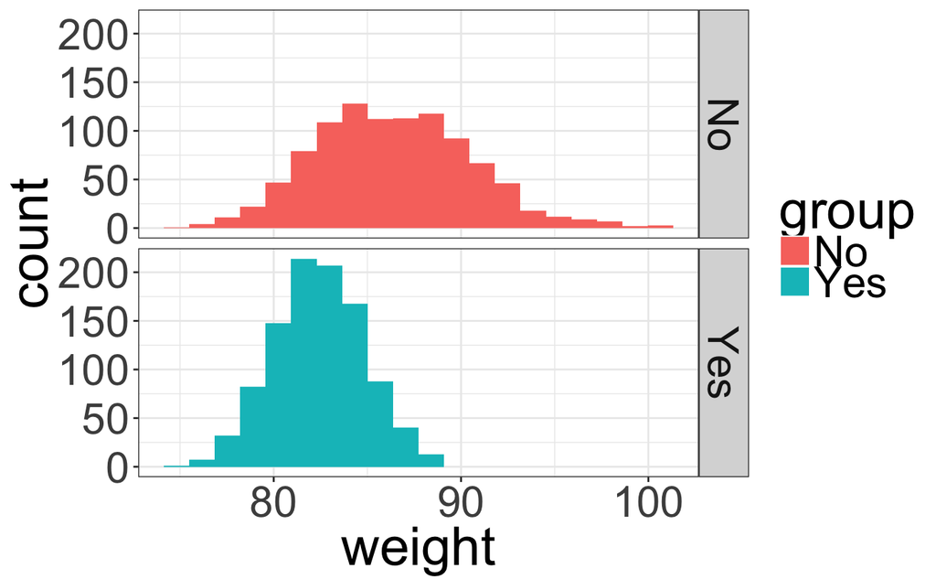

```r
active_means <- c()
inactive_means <- c()
# take 1000 samples
for (s in 1:1000) {
  bs_sample <- sample_n(NHANES_sample, 100, replace = TRUE)

  # save active mean
  active <- mean(bs_sample[bs_sample$PhysActive == 'Yes',]$Weight)
  active_means <- c(active_means, active)

  # save inactive mean
  inactive <- mean(bs_sample[bs_sample$PhysActive == 'No',]$Weight)
  inactive_means <- c(inactive_means, inactive)
}
# put means in a data frame
bs_df <- data.frame(Yes = active_means, No = inactive_means) %>%
  gather(group, weight)
# look at the sampling distributions
ggplot(bs_df, aes(weight, fill = group)) +
  facet_grid(group ~ .) +
  geom_histogram(bins = 20)
```

we can take the theoretical approach of using the normal distribution to find upper and lower confidence limits using these bootstrap means.

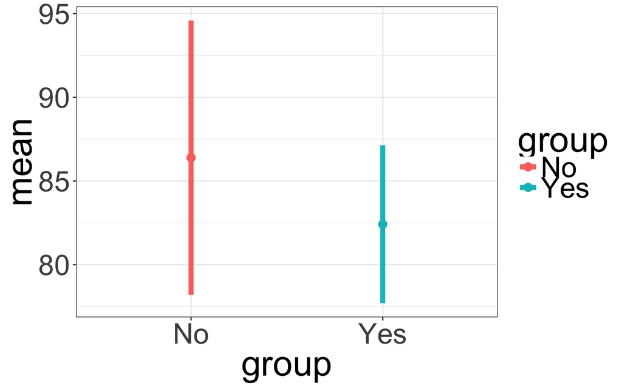

```r
bs_weight_summary <- bs_df %>%
  group_by(group) %>%
  summarise(n = n(),
            mean = mean(weight),
            sd = sd(weight),
            crit_val_lower = qnorm(.025),
            crit_val_upper = qnorm(.975),
            ci_lower = mean + crit_val_lower * sd,
            ci_upper = mean + crit_val_upper * sd)
ggplot(bs_weight_summary, aes(group, mean, color = group)) +
  geom_point(size = 3) +
  geom_errorbar(aes(ymin = ci_lower, ymax = ci_upper), width = 0, size = 2)
```

### empirical CI using sampling distribution

alternatively, we can compute empirical CIs with the percentile interval method. we simply take the 2.5th percentile and 97.5th percentile of the distribution of boostrap means to approximate the CI bounds.

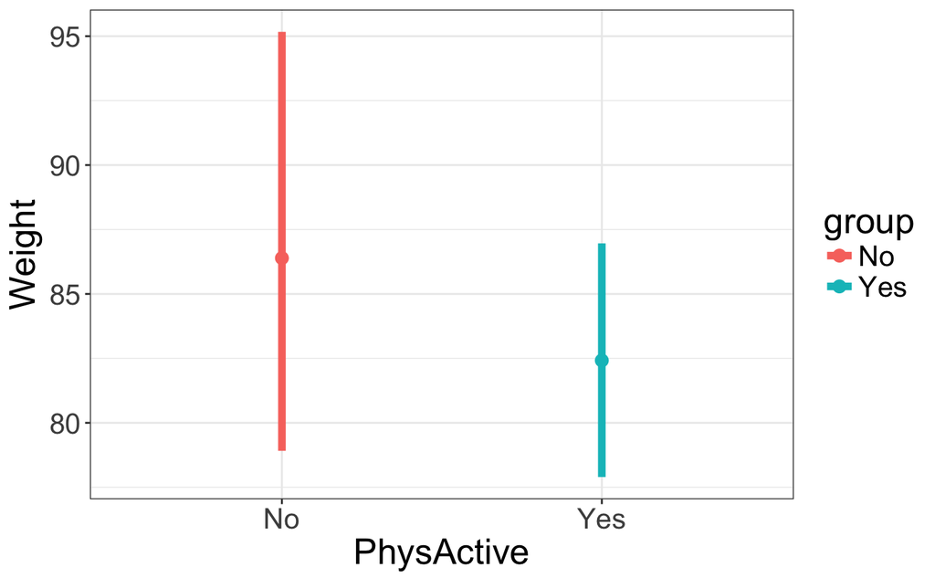

```r
bs_weight_empir_summary <- bs_df %>%
  group_by(group) %>%
  summarise(mean = mean(weight),
            ci_lower = quantile(weight, .025),
            ci_upper = quantile(weight, .975))
ggplot(bs_weight_empir_summary, aes(group, mean, color = group)) +
  geom_point(size = 3) +
  geom_errorbar(aes(ymin = ci_lower, ymax = ci_upper), width = 0, size = 2) +
  ylab("Weight") +
  xlab("PhysActive") +
  theme(text=element_text(size=20))
```